# DIALLO ALPHA OUMAR / TP SVM

# SVM Lineaire et non-lineaire

#### Application sur les donnees jouet (voir Hastie et Tibshrani)

```python
import numpy as np
import matplotlib.pyplot as plt
from matplotlib.colors import ListedColormap

import scipy.io as sio
from sklearn.metrics import accuracy_score, roc_curve
from sklearn.model_selection import train_test_split
from sklearn.preprocessing import StandardScaler

from sklearn.svm import SVC

from sklearn.linear_model import LogisticRegression
from sklearn.metrics import confusion_matrix
import matplotlib.pyplot as plt
import seaborn as sns

plt.close("all")
```

## Fonction qui trace la frontiere decision et marge

```python
def plot_decision_margin_2d(X, y, classifier, resolution=0.02, titre=' '):

    # setup marker generator and color map
    markers = ('s', 'v', 'o', '^', 'x')
    colors = ('red', 'blue', 'lightgreen', 'gray', 'cyan')
    cmap = ListedColormap(colors[:len(np.unique(y))])

    # plot the decision surface
    x1_min, x1_max = X[:, 0].min() - 0, X[:, 0].max() + 0
    x2_min, x2_max = X[:, 1].min() - 0, X[:, 1].max() + 0
    xx1, xx2 = np.meshgrid(np.arange(x1_min, x1_max, resolution),
                         np.arange(x2_min, x2_max, resolution))
    Z = classifier.predict(np.array([xx1.ravel(), xx2.ravel()]).T)
    Z = Z.reshape(xx1.shape)
    plt.figure()
    plt.contourf(xx1, xx2, Z, alpha=0.4, cmap=cmap)
    plt.xlim(xx1.min(), xx1.max())
    plt.ylim(xx2.min(), xx2.max())

    # margin
    Z = classifier.decision_function(np.array([xx1.ravel(), xx2.ravel()]).T)
    Z = Z.reshape(xx1.shape)
    cs = plt.contour(xx1, xx2, Z, levels=[-1, 0, 1], colors=['r', 'g', 'b'], linewidths=2.5)
    plt.clabel(cs)

    # plot class samples
    for idx, cl in enumerate(np.unique(y)):
        plt.scatter(x=X[y == cl, 0], y=X[y == cl, 1],
        alpha=0.45, color=colors[idx],
        marker=markers[idx], label='classe {}'.format(cl))
```

## Donnees apprentissage

```python
data_a = sio.loadmat('./mixtureexampleTRAIN.mat')
Xa, Ya = data_a['Xa'], data_a['Ya'][:,0]
print('\nCaractéristiques jeu apprentissage : ')
print('Nombre de points : {}'.format(Xa.shape[0]))
print('Nombre de variables : {}'.format(Xa.shape[1]))
print('Nombre de classes : {}'.format(len(np.unique(Ya))))
classes, nbpoints = np.unique(Ya, return_counts=True)
for i, lab in enumerate(classes):
    print('Classe {} comprend {} points'.format(lab, nbpoints[i]))
```

```
Caractéristiques jeu apprentissage :
Nombre de points : 1000
Nombre de variables : 2
Nombre de classes : 2
Classe -1 comprend 457 points
Classe 1 comprend 543 points
```

## Donnees test

```python
data_t = sio.loadmat('./mixtureexampleTEST.mat')
Xt, Yt = data_t['Xt'], data_t['Yt'][:,0]
print('\nCaractéristiques jeu de test : ')
classes, nbpoints = np.unique(Yt, return_counts=True)
for i, lab in enumerate(classes):
    print('Classe {} comprend {} points'.format(lab, nbpoints[i]))
```

```
Caractéristiques jeu de test :
Classe -1 comprend 94 points
Classe 1 comprend 107 points
```

### Decoupage des donnees app en jeu de validation et app

```python
Xa, Xv, Ya, Yv = train_test_split(Xa, Ya, shuffle=True, test_size=0.5, stratify=Ya)
```

### Normalisons nos données

```python
sc = StandardScaler(with_mean=True, with_std=True)
sc = sc.fit(Xa)
Xa = sc.transform(Xa)
Xv = sc.transform(Xv)
Xt = sc.transform(Xt)
```

### Visualisation des frontières suivant différentes valeurs de C

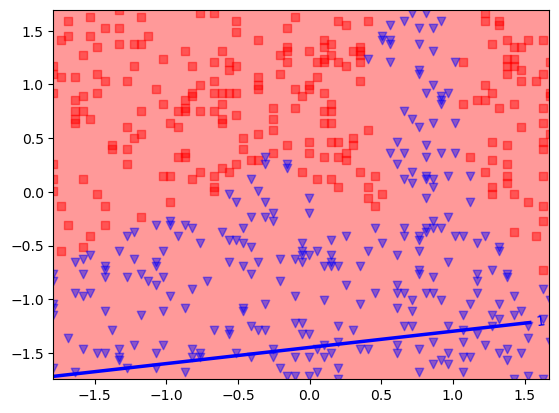

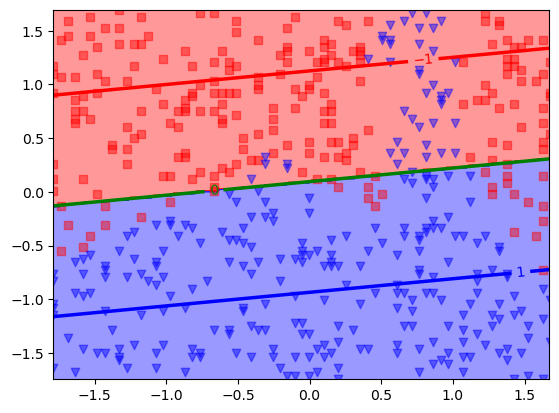

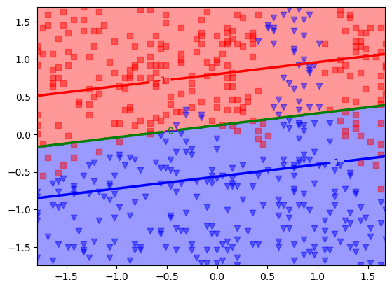

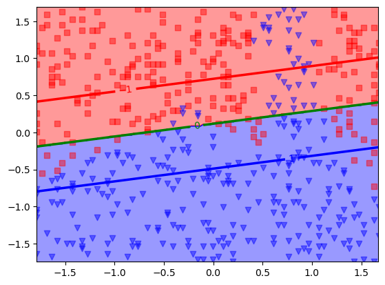

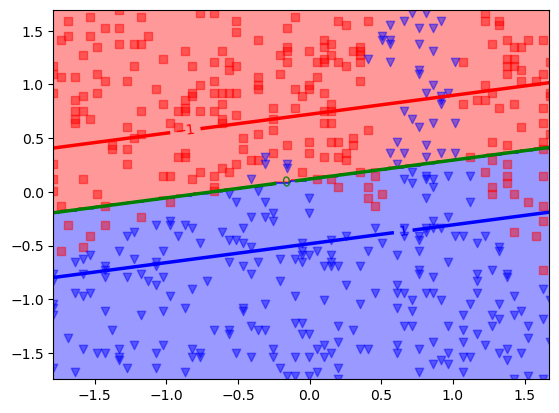

```python
vectC = np.logspace(-3, 1, 5)
paramKer = "auto"
for paramC in vectC:
    clf_svm = SVC(kernel='linear', C=paramC, gamma=paramKer)
    clf_svm.fit(Xa, Ya)
    plot_decision_margin_2d(Xa, Ya, clf_svm, 0.02, titre="C = {}".format(paramC))
```

L'observation de la frontières des points suivant la valeur de C nous montre que plus C est grand plus on a une séparatio optimale.On remarque que pour C=1 ou 10, on a une séparation plutot bonne même si on retrouve quelques points qui sont de mauvais coté

### Choix du C optimal par validation croisée

```python
vect = np.logspace(-3, 2, 15)
paramKer = "auto"
err_val = np.empty(vect.shape[0])
err_app = np.empty(vect.shape[0])
for ind_C, C in enumerate(vect):
    clf_svm1 = SVC(kernel='linear', C=C, gamma=paramKer)
    clf_svm1.fit(Xa, Ya)
    # Calcule l'erreur sur les données de validation et d'apprentissage
    err_val[ind_C] = 1 - accuracy_score(Yv, clf_svm1.predict(Xv))
    err_app[ind_C] = 1 - accuracy_score(Ya, clf_svm1.predict(Xa))

err_min_val, ind_min = err_val.min(), err_val.argmin()
Copt = vect[ind_min]
print("\n C optimal = {}".format(Copt))
```

```
 C optimal = 0.31622776601683794
```

# Traçons la courbe des erreurs

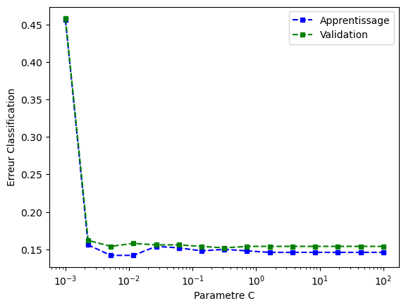

```python
plt.figure()
plt.semilogx(vect, err_app, color="blue", linestyle="--", marker="s", markersize=5, label="Apprentissage")
plt.semilogx(vect, err_val, color="green", linestyle="--", marker="s", markersize=5, label="Validation")
plt.xlabel("Parametre C")
plt.ylabel("Erreur Classification")
plt.legend(loc="best")
plt.show()
```

### Création du moddèle avec le meilleur C

```python
clf_svm = SVC(kernel='linear', C=Copt, gamma=paramKer)
clf_svm.fit(Xa,Ya)
```

```
SVC(C=0.31622776601683794, gamma='auto', kernel='linear')
```

### Visualisation de la séparation des poinst avec le C optimal

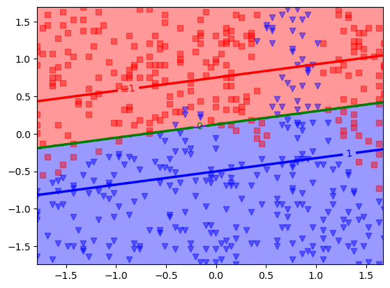

```python
plot_decision_margin_2d(Xa, Ya, clf_svm, 0.02, titre="C = {}".format(paramC))
```

#### Avec le meilleur paramètre C , nous avons notre meilleur séparation sur le grapge ci-dessus

### Evaluation sur les données de Train

```python
clf_svm.fit(Xa,Ya)
err_app = 1 - accuracy_score(Ya, clf_svm.predict(Xa))
print('erreur apprentissage :',err_app )
```

```
erreur apprentissage : 0.15000000000000002
```

### Evaluation sur les données Test

```python
err_test =1-accuracy_score(Yt, clf_svm.predict(Xt))
print('SVM linéaire : erreur test = {}'.format(err_test))
```

```
SVM linéaire : erreur test = 0.17910447761194026
```

# Extension aux données CTG

### Récuperation des données

```python
import pandas as pd
# Lecture et chargement des données
df = pd.read_csv("./CTGSimple.csv", sep="\t",header=1)
```

```python
df.head()
```

|  | b | e | AC | FM | UC | DL | DS | DP | DR | LB | ... | C | D | E | AD | DE | LD | FS | SUSP | CLASS | NSP |
| --- | --- | --- | --- | --- | --- | --- | --- | --- | --- | --- | --- | --- | --- | --- | --- | --- | --- | --- | --- | --- | --- |
| 0 | 240 | 357 | 0 | 0 | 0 | 0 | 0 | 0 | 0 | 120 | ... | -1 | -1 | -1 | -1 | -1 | -1 | 1 | -1 | 9 | 2 |
| 1 | 5 | 632 | 4 | 0 | 4 | 2 | 0 | 0 | 0 | 132 | ... | -1 | -1 | -1 | 1 | -1 | -1 | -1 | -1 | 6 | 1 |
| 2 | 177 | 779 | 2 | 0 | 5 | 2 | 0 | 0 | 0 | 133 | ... | -1 | -1 | -1 | 1 | -1 | -1 | -1 | -1 | 6 | 1 |
| 3 | 411 | 1192 | 2 | 0 | 6 | 2 | 0 | 0 | 0 | 134 | ... | -1 | -1 | -1 | 1 | -1 | -1 | -1 | -1 | 6 | 1 |
| 4 | 533 | 1147 | 4 | 0 | 5 | 0 | 0 | 0 | 0 | 132 | ... | -1 | -1 | -1 | -1 | -1 | -1 | -1 | -1 | 2 | 1 |

5 rows × 42 columns

```python
Y = df["NSP"].values
variables = ["LB","AC.1","FM.1","UC.1","DL.1","DS.1","DP.1","ASTV",
"MSTV","ALTV","MLTV", "Width","Min","Max","Nmax", "Nzeros","Mode","Mean","Median","Variance","Tendency"]
X = df[variables].values
```

#### Séparation des classess

```python
uniqLabels, counts = np.unique(Y, return_counts=True)
for i, lab in enumerate(uniqLabels):
    print("Classe {} contient {} points".format(lab, counts[i]))
corr_mat = np.corrcoef(X.T)
```

```
Classe 1 contient 1655 points
Classe 2 contient 295 points
Classe 3 contient 176 points
```

#### On associe la classe 2 et 3

```python
classe = 3
Y[np.in1d(Y, classe)] = 2
```

```python
Xa, Xt, Ya, Yt = train_test_split(X, Y, shuffle=True, test_size=1/2, stratify=Y)
```

### Normalisations des données

```python
from sklearn.preprocessing import StandardScaler
from sklearn.decomposition import PCA
from sklearn.svm import SVC
import numpy as np
import matplotlib.pyplot as plt
from matplotlib.colors import ListedColormap
```

```python
sc = StandardScaler(with_mean=True, with_std=True)
sc = sc.fit(Xa)
Xa = sc.transform(Xa)
Xt = sc.transform(Xt)
```

### Visualisation de la séparation des points suivant la valeur de C

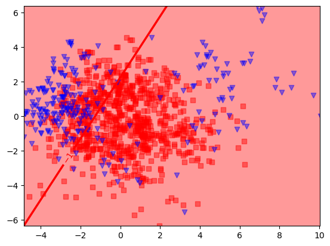

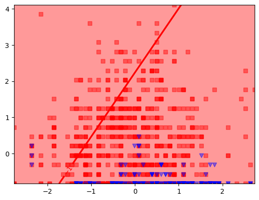

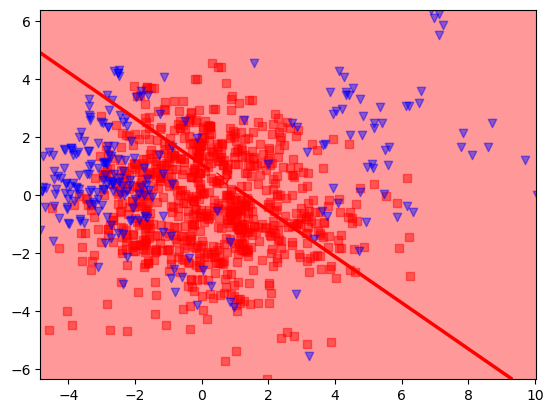

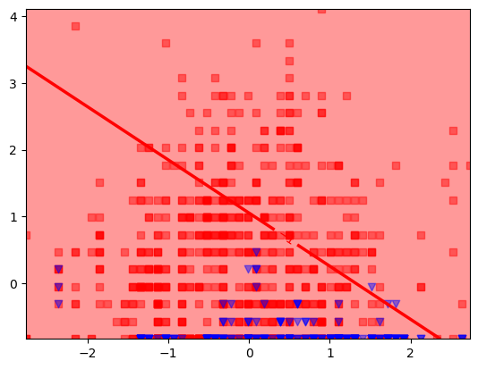

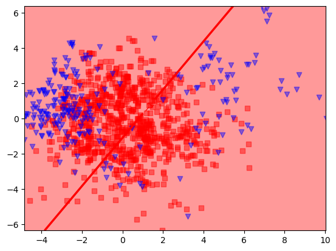

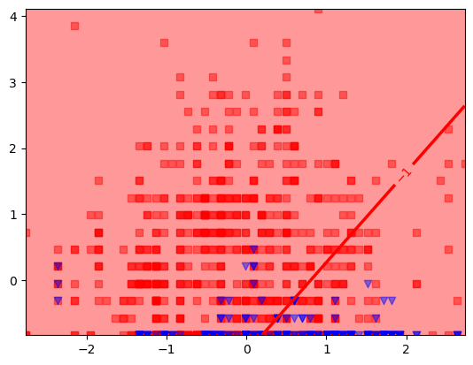

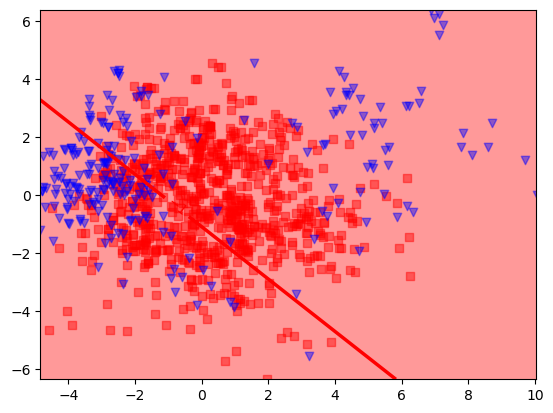

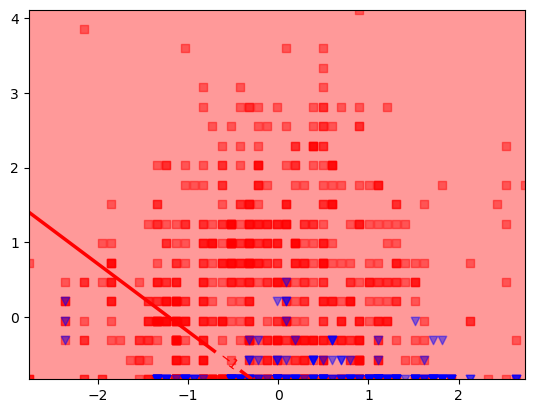

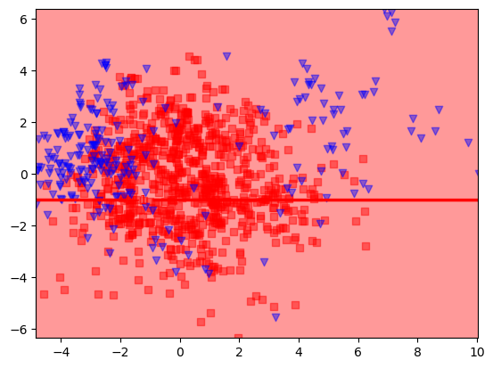

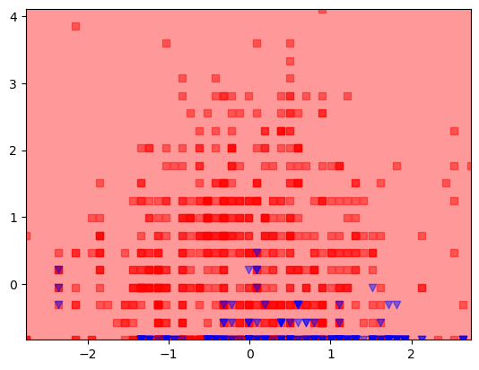

```python
# Réduction de dimensionnalité avec PCA
pca = PCA(n_components=2)
Xa_reduced = pca.fit_transform(Xa)

# Vecteur de différentes valeurs de C
vectC = np.logspace(-3, 1, 5)

# Boucle sur les différentes valeurs de C
for paramC in vectC:
    clf_svm = SVC(kernel='linear', C=paramC)
    clf_svm.fit(Xa_reduced, Ya)
    plt.figure()
    plot_decision_margin_2d(Xa_reduced, Ya, clf_svm, 0.02, titre="C = {}".format(paramC))
    plt.show()
    plot_decision_margin_2d(Xa, Ya, clf_svm, 0.02, titre="C = {}".format(paramC))
```

# Recherche du meilleur C*

```python
from sklearn.model_selection import GridSearchCV
from sklearn.svm import SVC
from sklearn.metrics import classification_report

# Paramètres à tester
param_grid = {'C': np.logspace(-3, 1, 5)}

# Grid Search avec validation croisée
grid_search = GridSearchCV(SVC(kernel='linear'), param_grid, cv=5, scoring='accuracy')
grid_search.fit(Xa, Ya)

# Meilleur paramètre C
best_C = grid_search.best_params_['C']
print("Meilleur C:", best_C)
```

```
Meilleur C: 1.0
```

```python
# Entraînement du modèle final avec le meilleur C
clf_svm_final = SVC(kernel='linear', C=best_C)
clf_svm_final.fit(Xa,Ya)
```

```
SVC(kernel='linear')
```

```python
# Évaluation sur l'ensemble de test
y_pred_svm = clf_svm_final.predict(Xt)
print(classification_report(Yt, y_pred_svm))
```

```
              precision    recall  f1-score   support

           1       0.92      0.94      0.93       827
           2       0.77      0.72      0.74       236

    accuracy                           0.89      1063
   macro avg       0.85      0.83      0.84      1063
weighted avg       0.89      0.89      0.89      1063
```

Le modèle montre une forte performance globale avec une accuracy de 89%, mais il est plus efficace pour identifier la classe 1 que la classe 2. Cela suggère un besoin d'amélioration dans la gestion de la classe 2, malgré les bons résultats généraux.Sa performance est quasiment la même que celle de la regression linéaire que nous avons vu dans le TP précédent

## Comparaison du modèle logistique linéaire et SVM linéaire

```python
# Entraînement du modèle de régression logistique
logreg = LogisticRegression(max_iter=1000)
logreg.fit(Xa, Ya)

# Prédictions pour la régression logistique et le modèle SVM
y_pred_logreg = logreg.predict(Xt)
y_pred_svm = clf_svm_final.predict(Xt)  # clf_svm_final est votre modèle SVM entraîné
```

```python
# Matrices de confusion
conf_matrix_logreg = confusion_matrix(Yt, y_pred_logreg)
conf_matrix_svm = confusion_matrix(Yt, y_pred_svm)
```

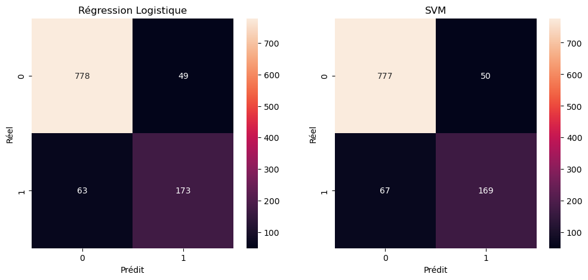

```python
# Affichage des matrices de confusion
fig, ax = plt.subplots(1, 2, figsize=(12, 5))

sns.heatmap(conf_matrix_logreg, annot=True, fmt="d", ax=ax[0])
ax[0].set_title("Régression Logistique")
ax[0].set_xlabel("Prédit")
ax[0].set_ylabel("Réel")

sns.heatmap(conf_matrix_svm, annot=True, fmt="d", ax=ax[1])
ax[1].set_title("SVM")
ax[1].set_xlabel("Prédit")
ax[1].set_ylabel("Réel")

plt.show()
```

Comme on le voit sur les matrices des confusions ci dessus les deux modèles ont quasiemnt les mêmes performances Le modèl logistique fait légèrement mieux.

## SVM NON LINEAIRE

#### Préparation des Données

```python
# Chargement des données
data_a_nl = sio.loadmat('./mixtureexampleTRAIN.mat')
Xa_nl, Ya_nl = data_a_nl['Xa'], data_a_nl['Ya'][:,0]

# Affichage des caractéristiques du jeu d'apprentissage
print('\nCaractéristiques jeu apprentissage (non linéaire) : ')
print('Nombre de points : {}'.format(Xa_nl.shape[0]))
print('Nombre de variables : {}'.format(Xa_nl.shape[1]))
print('Nombre de classes : {}'.format(len(np.unique(Ya_nl))))

# Comptage des points par classe
classes_nl, nbpoints_nl = np.unique(Ya_nl, return_counts=True)
for i, lab in enumerate(classes_nl):
    print('Classe {} comprend {} points'.format(lab, nbpoints_nl[i]))
```

```
Caractéristiques jeu apprentissage (non linéaire) :
Nombre de points : 1000
Nombre de variables : 2
Nombre de classes : 2
Classe -1 comprend 457 points
Classe 1 comprend 543 points
```

```python
# Données TEST
data_t_nl = sio.loadmat('./mixtureexampleTEST.mat')
Xt_nl, Yt_nl = data_t_nl['Xt'], data_t_nl['Yt'][:,0]

# Affichage des caractéristiques du jeu de test
print('\nCaractéristiques jeu de test (non linéaire) : ')
classes_t_nl, nbpoints_t_nl = np.unique(Yt_nl, return_counts=True)
for i, lab in enumerate(classes_t_nl):
    print('Classe {} comprend {} points'.format(lab, nbpoints_t_nl[i]))
```

```
Caractéristiques jeu de test (non linéaire) :
Classe -1 comprend 94 points
Classe 1 comprend 107 points
```

### Decoupage des donnees app en jeu de validation et app

```python
validation_size = 0.2

# Séparation des données
Xa_train_nl, Xa_val_nl, Ya_train_nl, Ya_val_nl = train_test_split(Xa_nl, Ya_nl, test_size=validation_size)

print("Taille des données d'entraînement : ", Xa_train_nl.shape)
print("Taille des données de validation : ", Xa_val_nl.shape)
```

```
Taille des données d'entraînement :  (800, 2)
Taille des données de validation :  (200, 2)
```

### Normalisation des Données

```python
# Création de l'objet StandardScaler
scaler = StandardScaler()

# Ajustement du scaler sur les données d'entraînement uniquement
scaler.fit(Xa_train_nl)

# Transformation des ensembles d'entraînement et de validation
Xa_train_nl_scaled = scaler.transform(Xa_train_nl)
Xa_val_nl_scaled = scaler.transform(Xa_val_nl)

Xt_nl_scaled = scaler.transform(Xt_nl)
```

### Marges de décision du modèle SVM suivant C avec le noyau Gaussien

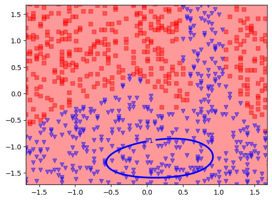

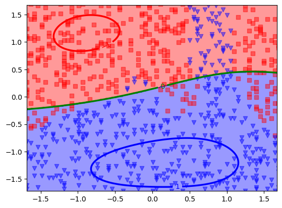

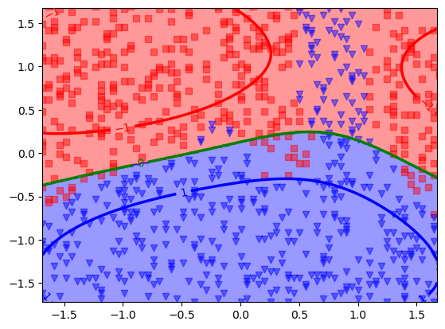

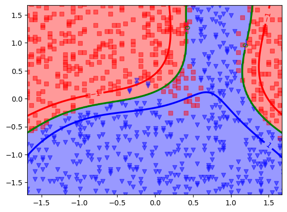

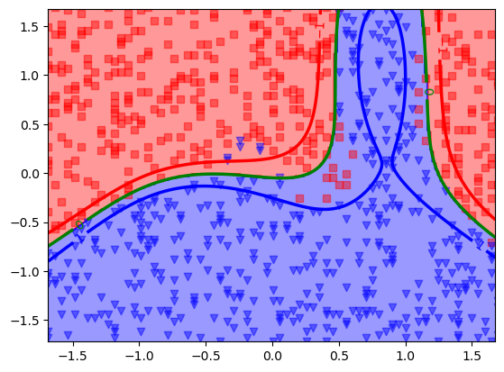

```python
# Définir une gamme de valeurs pour C
vectC = np.logspace(-3, 1, 5)

# Boucle sur les différentes valeurs de C
for paramC in vectC:
    # Créer et entraîner le modèle SVM non linéaire avec le noyau de votre choix, par exemple 'rbf'
    clf_svm_nl = SVC(kernel='rbf', C=paramC)
    clf_svm_nl.fit(Xa_train_nl_scaled, Ya_train_nl)

    # Tracer les marges de décision
    plt.figure()
    plot_decision_margin_2d(Xa_train_nl_scaled, Ya_train_nl, clf_svm_nl, 0.02, titre=f"C = {paramC}")
    plt.show()
```

Nous remarquons à travers ces graphes que, à mesure que la valeur de C augmente, les marges de décision du modèle SVM avec noyau RBF deviennent plus précises et mieux définies. Cela suggère une capacité accrue à distinguer entre les classes. Cette tendance illustre l'impact de C sur la tolérance du modèle aux erreurs de classification : un C plus élevé entraîne une classification plus rigoureuse, réduisant la marge d'erreur et potentiellement améliorant la séparation des classes. Nous observons clairement une meilleure séparation que pour le modèle linéaire.

### On fixe maintenant le paramètre de régularisation à C = 1

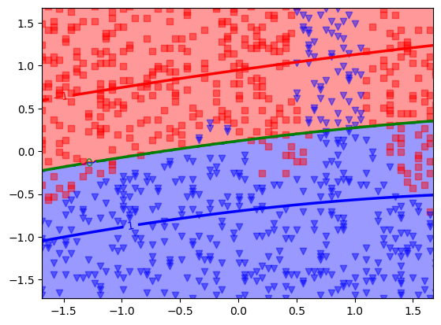

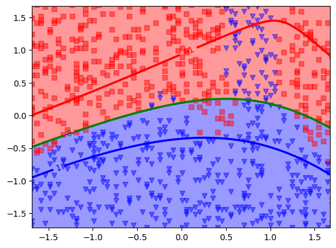

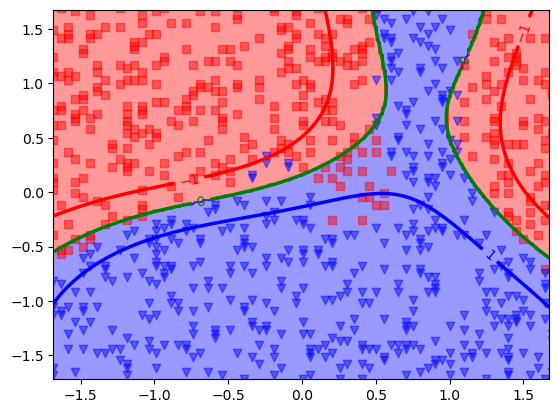

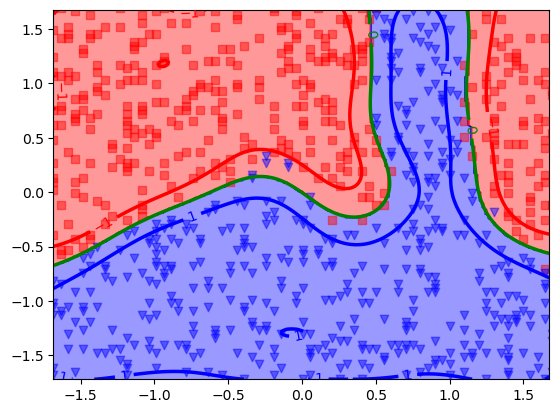

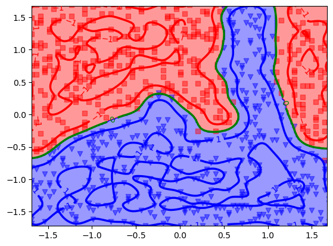

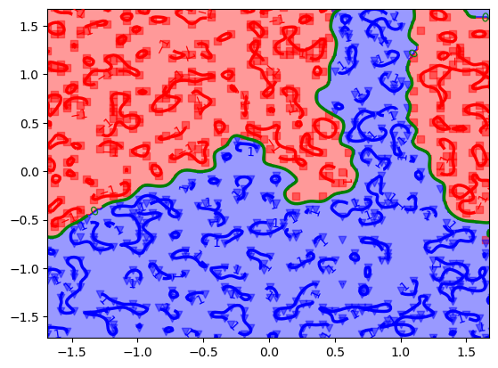

```python
# Initialisation du classifieur SVM avec le noyau RBF
clf_ker = SVC(kernel='rbf', C=1)
vectGamma = np.logspace(-2, 2, 6)

# Boucle sur les différentes valeurs de gamma
for paramKer in vectGamma:
    clf_ker.gamma = paramKer
    clf_ker.fit(Xa_train_nl_scaled, Ya_train_nl)
    plot_decision_margin_2d(Xa_train_nl_scaled, Ya_train_nl, clf_ker, 0.02, titre="gamma = {}".format(paramKer))
    plt.show()
```

Les graphiques montrent qu'avec l'augmentation de γ dans le SVM avec noyau RBF, les frontières de décision tendent à devenir plus complexes et précises, reflétant une meilleure séparation entre les classes. Cependant, une valeur élevée de γ peut aussi mener à un surajustement, où le modèle s'adapte trop spécifiquement aux données d'entraînement, compromettant sa capacité à généraliser. Il est donc essentiel d'équilibrer la valeur de γ pour éviter ce risque.

### Grid Search pour les Hyperparemètres

Pour sélectionner de manière optimale ces hyper-paramètres, nous allons faire une recherche en grille (Grid Search). Cette méthode consiste à tester toutes les combinaisons possibles de valeurs pour C et γ dans des plages prédéfinies et à évaluer les performances de chaque combinaison d'hyper-paramètres sur un ensemble de validation.

```
- Apprentissage du SVM pour C =  0.001
	 Apprentissage du SVM pour gamma =   0.01
	 Apprentissage du SVM pour gamma =   0.06
	 Apprentissage du SVM pour gamma =   0.40
	 Apprentissage du SVM pour gamma =   2.51
	 Apprentissage du SVM pour gamma =  15.85
	 Apprentissage du SVM pour gamma = 100.00
- Apprentissage du SVM pour C =  0.010
	 Apprentissage du SVM pour gamma =   0.01
	 Apprentissage du SVM pour gamma =   0.06
	 Apprentissage du SVM pour gamma =   0.40
	 Apprentissage du SVM pour gamma =   2.51
	 Apprentissage du SVM pour gamma =  15.85
	 Apprentissage du SVM pour gamma = 100.00
- Apprentissage du SVM pour C =  0.100
	 Apprentissage du SVM pour gamma =   0.01
	 Apprentissage du SVM pour gamma =   0.06
	 Apprentissage du SVM pour gamma =   0.40
	 Apprentissage du SVM pour gamma =   2.51
	 Apprentissage du SVM pour gamma =  15.85
	 Apprentissage du SVM pour gamma = 100.00
- Apprentissage du SVM pour C =  1.000
	 Apprentissage du SVM pour gamma =   0.01
	 Apprentissage du SVM pour gamma =   0.06
	 Apprentissage du SVM pour gamma =   0.40
	 Apprentissage du SVM pour gamma =   2.51
	 Apprentissage du SVM pour gamma =  15.85
	 Apprentissage du SVM pour gamma = 100.00
- Apprentissage du SVM pour C = 10.000
	 Apprentissage du SVM pour gamma =   0.01
	 Apprentissage du SVM pour gamma =   0.06
	 Apprentissage du SVM pour gamma =   0.40
	 Apprentissage du SVM pour gamma =   2.51
	 Apprentissage du SVM pour gamma =  15.85
	 Apprentissage du SVM pour gamma = 100.00
- Apprentissage du SVM pour C = 100.000
	 Apprentissage du SVM pour gamma =   0.01
	 Apprentissage du SVM pour gamma =   0.06
	 Apprentissage du SVM pour gamma =   0.40
	 Apprentissage du SVM pour gamma =   2.51
	 Apprentissage du SVM pour gamma =  15.85
	 Apprentissage du SVM pour gamma = 100.00
```

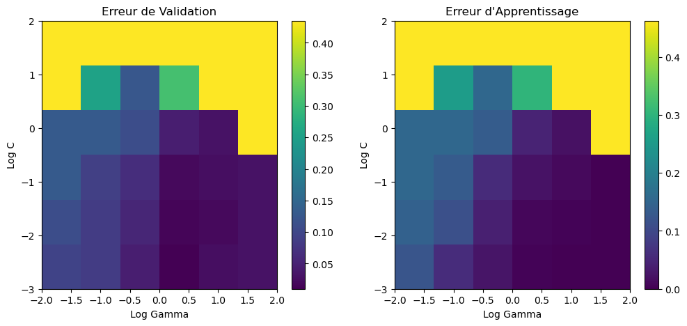

```python
# Initialisation des vecteurs C et gamma
vectC = np.logspace(-3, 2, 6)
vectGamma = np.logspace(-2, 2, 6)

# Initialisation des tableaux d'erreurs
err_val = np.empty((len(vectC), len(vectGamma)))
err_app = np.empty((len(vectC), len(vectGamma)))

# Boucle sur les valeurs de C
for ind_C, C in enumerate(vectC):
    print("- Apprentissage du SVM pour C = {:6.3f} ".format(C))
    clf_ker = SVC(kernel='rbf', C=C)

    # Boucle sur les valeurs de gamma
    for ind_gam, gamma in enumerate(vectGamma):
        print("\t Apprentissage du SVM pour gamma = {:6.2f} ".format(gamma))
        clf_ker.gamma = gamma
        clf_ker.fit(Xa_train_nl_scaled, Ya_train_nl)

        # Calcul des erreurs
        err_val[ind_C, ind_gam] = 1 - accuracy_score(Ya_val_nl, clf_ker.predict(Xa_val_nl_scaled))
        err_app[ind_C, ind_gam] = 1 - accuracy_score(Ya_train_nl, clf_ker.predict(Xa_train_nl_scaled))

# Visualisation des erreurs
plt.figure(figsize=(12, 5))

# Erreur de validation
plt.subplot(121)
plt.imshow(err_val, aspect="auto", extent=[np.log10(vectGamma[0]), np.log10(vectGamma[-1]), np.log10(vectC[0]), np.log10(vectC[-1])])
plt.xlabel('Log Gamma')
plt.ylabel('Log C')
plt.title("Erreur de Validation")
plt.colorbar()

# Erreur d'apprentissage
plt.subplot(122)
plt.imshow(err_app, aspect="auto", extent=[np.log10(vectGamma[0]), np.log10(vectGamma[-1]), np.log10(vectC[0]), np.log10(vectC[-1])])
plt.xlabel('Log Gamma')
plt.ylabel('Log C')
plt.title("Erreur d'Apprentissage")
plt.colorbar()

plt.show()
```

### Sélection de la valeur optimale de C et γ

```python
ind_C, ind_gamma = np.unravel_index(np.argmin(err_val), err_val.shape)

# Sélectionner les valeurs optimales de C et gamma
Copt = vectC[ind_C]
GammaOpt = vectGamma[ind_gamma]

print("Meilleur C: ", Copt)
print("Meilleur gamma: ", GammaOpt)
```

```
Meilleur C:  100.0
Meilleur gamma:  2.5118864315095824
```

### TEST du modèle avec les paramètres optimaux

```python
# Initialisation du modèle SVM avec les meilleurs hyper-paramètres
clf_ker = SVC(kernel='rbf', C=Copt, gamma=GammaOpt)

# Entraînement du modèle sur l'ensemble d'apprentissage
clf_ker.fit(Xa_train_nl_scaled, Ya_train_nl)

# Calcul et affichage de l'erreur d'apprentissage
err_app = 1 - accuracy_score(Ya_train_nl, clf_ker.predict(Xa_train_nl_scaled))
print("\nSVM kernel optimal : erreur apprentissage = {:.2f}%".format(100 * err_app))

# Calcul et affichage de l'erreur de validation
err_val = 1 - accuracy_score(Ya_val_nl, clf_ker.predict(Xa_val_nl_scaled))
print("SVM kernel optimal : erreur validation = {:.2f}%".format(100 * err_val))

# Calcul et affichage de l'erreur de test (si disponible)

err_test = 1 - accuracy_score(Yt_nl, clf_ker.predict(Xt_nl_scaled))
print("SVM kernel optimal : erreur test = {:.2f}%".format(100 * err_test))
```

```
SVM kernel optimal : erreur apprentissage = 0.38%
SVM kernel optimal : erreur validation = 1.00%
SVM kernel optimal : erreur test = 1.49%
```

Ces résultats indiquent un modèle SVM bien ajusté et robuste, avec d'excellentes capacités de généralisation. L'écart minime entre les erreurs d'apprentissage, de validation et de test suggère que le modèle n'est pas en surajustement (overfitting). Nous avons donc un très bon modèle qui est largement supérieur au modèle linéaire.

# Utilisation du noyeau polynomiale

### Grid Search pour le SVM avec Noyau Polynomial

```python
# Définition des plages d'hyper-paramètres à explorer
param_grid_poly = {'C': np.logspace(-3, 2, 6),
                   'degree': [2, 3, 4, 5]}

# Création de l'objet GridSearchCV pour un SVM avec noyau polynomial
grid_search_poly = GridSearchCV(SVC(kernel='poly'), param_grid_poly, cv=5, scoring='accuracy')

# Entraînement du modèle sur l'ensemble d'apprentissage
grid_search_poly.fit(Xa_train_nl_scaled, Ya_train_nl)

# Affichage des meilleurs hyper-paramètres
print("Meilleurs hyper-paramètres (poly): ", grid_search_poly.best_params_)
```

```
Meilleurs hyper-paramètres (poly):  {'C': 100.0, 'degree': 3}
```

### Choix et entrainement du modèle

```python
# Création du modèle SVM avec les meilleurs hyper-paramètres trouvés
clf_ker_poly = SVC(kernel='poly', C=grid_search_poly.best_params_['C'], degree=grid_search_poly.best_params_['degree'])

# Entraînement du modèle
clf_ker_poly.fit(Xa_train_nl_scaled, Ya_train_nl)
```

```
SVC(C=100.0, kernel='poly')
```

### TEST DU MODEL

```python
# Calcul des erreurs
err_app_poly = 1 - accuracy_score(Ya_train_nl, clf_ker_poly.predict(Xa_train_nl_scaled))
print("\nSVM kernel polynomial optimal : erreur apprentissage = {:.2f}%".format(100 * err_app_poly))

err_val_poly = 1 - accuracy_score(Ya_val_nl, clf_ker_poly.predict(Xa_val_nl_scaled))
print("SVM kernel polynomial optimal : erreur validation = {:.2f}%".format(100 * err_val_poly))

err_test_poly = 1 - accuracy_score(Yt_nl, clf_ker_poly.predict(Xt_nl_scaled))
print("SVM kernel polynomial optimal : erreur test = {:.2f}%".format(100 * err_test_poly))
```

```
SVM kernel polynomial optimal : erreur apprentissage = 16.87%
SVM kernel polynomial optimal : erreur validation = 16.00%
SVM kernel polynomial optimal : erreur test = 17.41%
```

Nous remarquons que le modèle SVM avec noyau polynomial présente des erreurs globalement plus élevées comparé au modèle avec noyau RBF sur notre jeu de données. Ceci suggère que le noyau RBF, plus flexible, est mieux adapté pour capturer les complexités de ces données spécifiques. Les faibles écarts entre les erreurs d'apprentissage, de validation et de test indiquent une performance constante du modèle polynomial, mais son niveau d'erreur général plus élevé souligne l'importance cruciale du choix du noyau en fonction des caractéristiques des données.